# Communicate Data Findings Project

The project have two parts which demonstrate the value of data visualization techniques in the data analysis process and why is it important. First part of the project, I will be using the Python visualization libraries to systematically explore the dataset that was selected, started from the plots of each single variables and build up plots of multiple variables.The second part, I will illustrates the interesting properties, trends, and the relationships that was discovered in the selected dataset. The primary method of conveying the findings through the transforming of the exploratory visualizations from the first part into polished, explanatory visualizations.

# Ford GoBike System

The pie graph shows the number of users were the male has the higher percentage number of users compared to female and others

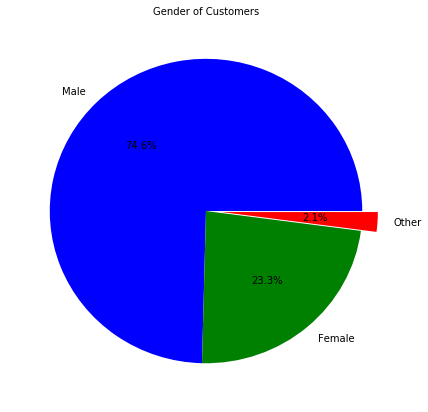

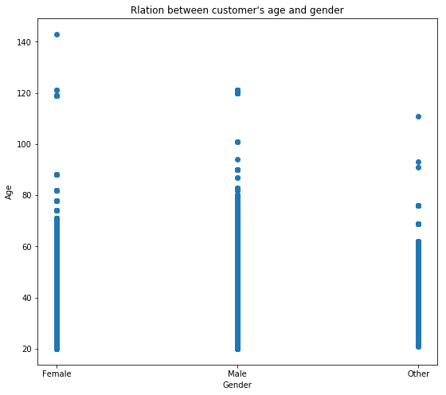

The bar chart illustrates that more male users than female and others

```
Text(0,0.5,'Customer')
```

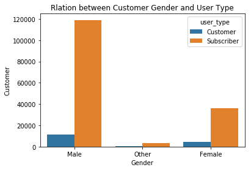

The plot represents the relation between age and user type

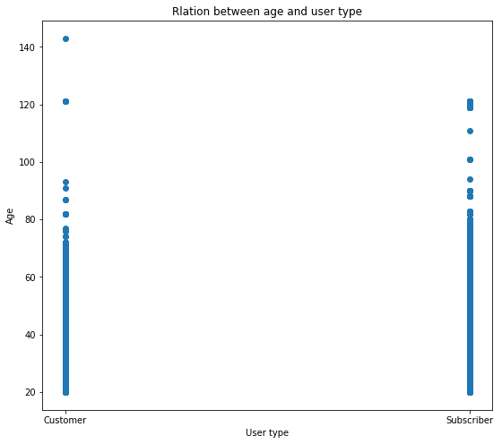

The bar chart shows how many hours the users use the bike

```
Text(0,0.5,'Number of Users')
```

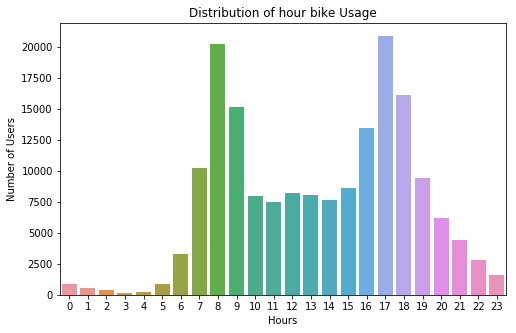

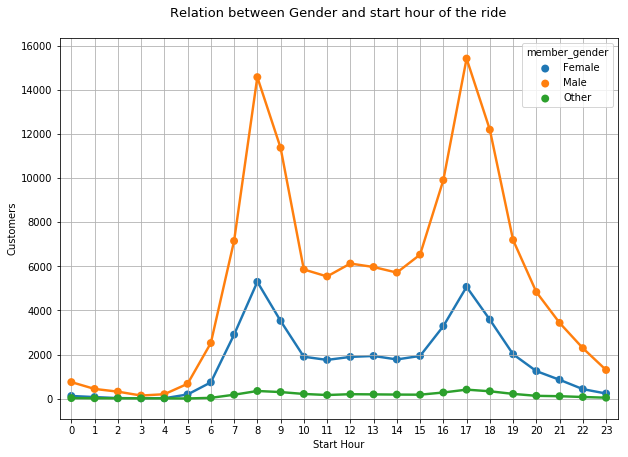

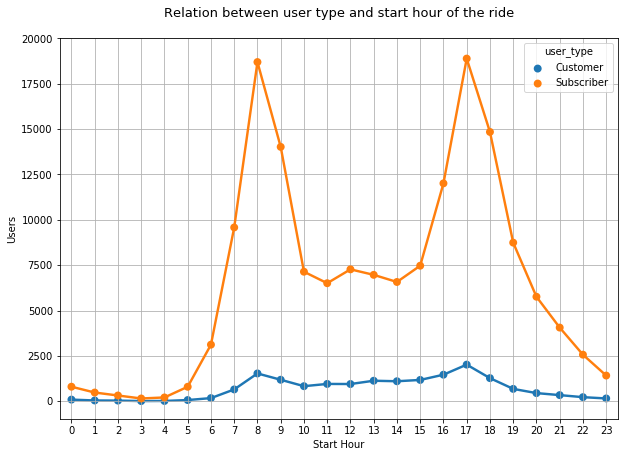

```
Text(0,0.5,'member_gender')
```

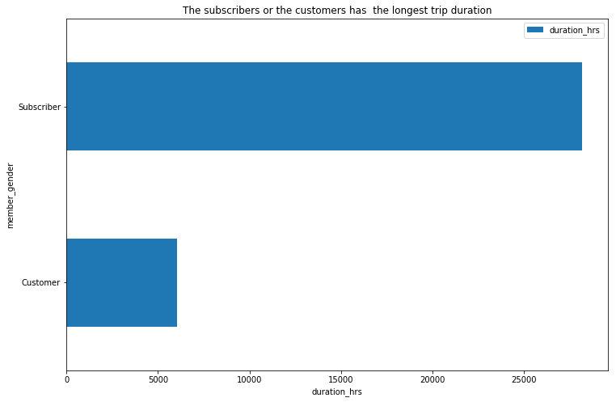

```
Text(0,0.5,'member_gender')
```

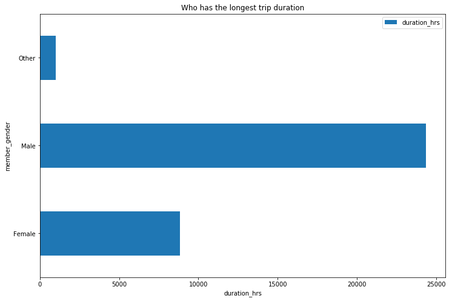

```
[NbConvertApp] Converting notebook CommunicateDataFind.ipynb to slides
[NbConvertApp] Writing 506201 bytes to CommunicateDataFind.slides.html
```

[output not shown]